# Análise Ambiental

Conceitos e Definições da  
Análise Ambiental

Luiz Diego Vidal Santos

## Visão Geral da Aula

### Tópicos

- 1 Ambiente e impacto ambiental
- 2 Degradação e vulnerabilidade
- 3 Fragilidade ambiental
- 4 Risco e resiliência
- 5 Recuperação ambiental
- 6 Sustentabilidade
- 7 Estudo Orientado nº 3 (entrega na aula seguinte)

**Objetivo da Aula**

Operacionalizar o vocabulário conceitual da análise ambiental (impacto, degradação, vulnerabilidade, fragilidade, risco, resiliência e sustentabilidade) como base para o diagnóstico integrado.

# 1 - IMPACTO E DEGRADAÇÃO

## Definições operacionais

### Impacto ambiental

- **Conceito** (Sánchez, 2013): alteração da qualidade ambiental resultante de uma ação humana, comparada a uma situação **sem** essa ação.
- **Marco legal**: Res. CONAMA 01/1986, Art. 1º - “qualquer alteração das propriedades físicas, químicas e biológicas… que afete… a saúde, a segurança e o bem-estar… atividades sociais e econômicas… a biota… condições estéticas e sanitárias… qualidade dos recursos”.

### Atributos do impacto

| Atributo | Variantes |
| --- | --- |
| Valoração | Positivo / negativo |
| Magnitude | Pequena / média / grande |
| Duração | Temporário / permanente |
| Reversibilidade | Reversível / irreversível |
| Distribuição | Local / regional / global |
| Interação | Aditivo / cumulativo / sinérgico |

**Degradação ambiental**

Processo de **redução cumulativa** das capacidades funcionais do sistema ambiental:

- Perda da **produtividade biológica**
- Perda de **diversidade**
- Perda da **capacidade de regulação** (hídrica, climática, biogeoquímica)

> Impacto é **evento**; degradação é **processo cumulativo** que reorganiza estruturas e funções (Tauk-Tornisielo, 1996).

## Vulnerabilidade e fragilidade

### Vulnerabilidade

- **Capacidade de sofrer dano** diante de uma perturbação.
- Função de **exposição × sensibilidade × capacidade adaptativa** (IPCC).
- Dimensão **socioambiental**: combina condições do meio físico-biótico e atributos sociais da população exposta.

### Fragilidade ambiental (Ross, 1994)

- Conceito operacionalizado para o **planejamento territorial brasileiro**.
- Combina atributos do meio físico (solo, relevo, clima, vegetação) em hierarquias de fragilidade.
- Distingue duas formas:
  - **Fragilidade potencial** - propriedades intrínsecas (geologia, declividade, solo, clima)
  - **Fragilidade emergente** - fragilidade potencial **modificada pelo uso da terra**

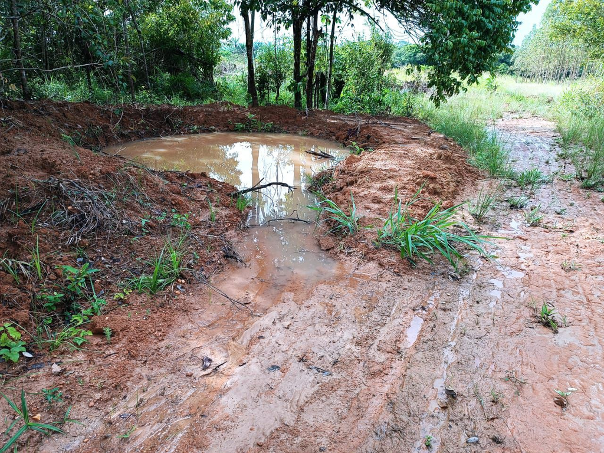

**Vulnerabilidade × fragilidade**

| Termo | Eixo dominante | Aplicação |
| --- | --- | --- |
| **Vulnerabilidade** | Sócio-econômico-ambiental | Mudanças climáticas, riscos urbanos |
| **Fragilidade** | Físico-biótico | Cartografia para planejamento territorial |

Na prática, a Análise Ambiental opera frequentemente com a **fragilidade emergente** (Ross) como expressão sintética para o planejamento.

# 2 - RISCO, RESILIÊNCIA, RECUPERAÇÃO

## Risco e resiliência

### Risco

- Probabilidade × magnitude do dano.
- Tradicionalmente: $R = P \times C$ (probabilidade × consequência).
- Em sistemas socioambientais: $R = f(\text{Perigo}, \text{Exposição}, \text{Vulnerabilidade})$.

### Tipos de risco ambiental

| Risco | Exemplo |
| --- | --- |
| Geomorfológico | Movimentos de massa, erosão acelerada |
| Hidrológico | Inundações, enxurradas, secas |
| Geotécnico | Recalques, instabilidade de taludes |
| Tecnológico | Vazamentos, barragens, dutos |
| Biológico | Espécies invasoras, zoonoses |

**Resiliência**

Capacidade do sistema de **absorver perturbações** mantendo sua estrutura e funções essenciais (Holling, 1973).

| Dimensão | Pergunta-guia |
| --- | --- |
| **Engenharia** | Quão rápido o sistema volta ao estado anterior? |
| **Ecológica** | Quanto pode absorver antes de mudar de estado? |
| **Adaptativa** | Como aprende e se reorganiza após o distúrbio? |

> Sistemas pouco resilientes têm **limiares baixos** - pequenas perturbações induzem mudanças de estado (ex.: solo desestruturado → voçoroca).

## Recuperação e sustentabilidade

### Gradiente de intervenção (SER, 2004; Sánchez, 2013)

| Termo | Objetivo |
| --- | --- |
| **Restauração** | Restabelecer composição, estrutura e função análogas ao ecossistema de referência |
| **Recuperação** | Restabelecer funções básicas (cobertura, hidrologia, solo) sem exigir analogia com referência |
| **Reabilitação** | Reorientar o uso para outras funções produtivas/ecológicas |
| **Mitigação** | Atenuar dano sem revertê-lo plenamente |
| **Compensação** | Equivalência em outro local quando não é possível restaurar |

> No marco legal brasileiro, **PRAD** (Plano de Recuperação de Áreas Degradadas) é o instrumento operacional.

**Sustentabilidade**

- Brundtland (1987): atender às necessidades do presente sem comprometer as gerações futuras.
- **Três pilares**: ecológico, econômico, social - e, mais recentemente, **cultural** e **institucional**.
- **ODS (Agenda 2030)**: 17 objetivos territorializáveis (especialmente ODS 6, 13, 14, 15).

### Estudo Orientado nº 3 (entrega na aula seguinte)

Fichar SÁNCHEZ (2013), cap. 1, **Conceitos e definições**, conforme o roteiro geral de fichamento (contexto e tese central, conceitos operacionais, aplicação, crítica e síntese), aplicando ao **território de estudo**: distinguir **degradação** de **impacto ambiental**, identificar os **processos ambientais** em curso e avaliar o potencial de **resiliência** e **recuperação**.

# Referências

## Bibliografia da aula

- SÁNCHEZ, L. E. Conceitos e definições. In: **Avaliação de impacto ambiental**: conceitos e métodos. 2. ed. São Paulo: Oficina de Textos, 2013. cap. 1.
- TAUK-TORNISIELO, S. M. **Análise ambiental**: uma visão multidisciplinar. São Paulo: Unesp, 1996.